# FigureYa273BAPC

**Author(s)**: Xiaofan Lu; Yasi Zhang  
**Reviewer(s)**: Ying Ge  
**Date**: 2025-05-20

# 需求描述

# Requirement Description

需要做贝叶斯-年龄队列预测分析，画出文章中的Figure 3。

Need to perform Bayesian age-period-cohort prediction analysis and plot Figure 3 from the paper.

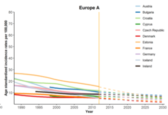

出自：https://www.sciencedirect.com/science/article/abs/pii/S001650852100531X#abssec0020

图3 按大洲划分的43个国家胃癌年龄标准化发病率趋势，**实线为观察值，虚线为预测值**。

Source: https://www.sciencedirect.com/science/article/abs/pii/S001650852100531X#abssec0020

Figure 3 Trends in **observed (solid lines) and predicted (dashed lines)** age-standardized incidence rates of gastric cancer in 43 countries by continent.

# 应用场景

# Application Scenario

贝叶斯年龄-时期-队列预测模型 (Bayesian-age-period-cohort [BAPC] model)

Bayesian age-period-cohort prediction model (Bayesian-age-period-cohort [BAPC] model)

# 环境设置

# Environment Setup

使用国内镜像安装包

Using domestic mirrors for package installation.

```r
options("repos"= c(CRAN="https://mirrors.tuna.tsinghua.edu.cn/CRAN/"))
options(BioC_mirror="http://mirrors.tuna.tsinghua.edu.cn/bioconductor/")
install.packages("bamp")
```

# 加载包

# Loading packages

```r
# 加载用于估计BAPC模型及进行预测的R包
# Load R package for estimating BAPC model and making predictions
library(bamp)
# 显示英文报错信息
# Display English error messages
Sys.setenv(LANGUAGE = "en")

# 禁止chr转成factor
# Prevent character conversion to factor
options(stringsAsFactors = FALSE)
```

# 输入文件

# Input Files

原始数据结构说明：

- 1、Oceania.csv 为Oceania总体信息，包括每个国家具体区域或城市的id（即，REGISTRY），统计数据起止年份（YEAR1和YEAR2）
- 2、原始数据 Oceania_Pos.csv，为每个国家每个城市每年每个年龄组的具体人口数据
- 3、原始数据 Oceania_Cases.csv，为每个国家每个城市每年每个年龄组的具体病例数据

注意：

Data structure description:

- 1. Oceania.csv contains overall information for Oceania, including id for each country’s specific region or city (REGISTRY), start and end years of statistics (YEAR1 and YEAR2).
- 2. Original data Oceania_Pos.csv contains specific population data for each city’s each age group each year.
- 3. Original data Oceania_Cases.csv contains specific case data for each city’s each age group each year.

Notes:

```r
# 初始化计算时间
# # Initialize calculation time
timestart <- Sys.time()

### Oceania ####
### 人口数据
### Population data
oce_pop <- read.csv("Oceania_Pops.csv", header = T)

# 从原始数据中拆分出Australia的人口数据
# 注意： seq(3600200, 3600800, 100)为Australia的城市或区域id
# Extract Australia population data from raw data
# Note: seq(3600200, 3600800, 100) are city/region ids for Australia

# 合并Australia所有区域或城市的人口数据，并提取1988年以后数据
# Combine population data for all Australia regions/cities and extract data since 1988
Australia <- oce_pop[(oce_pop$REGISTRY %in% seq(3600200, 3600800, 100)) & (oce_pop$YEAR >= 1988), ]

# 将年份从小到大排序
# Sort years in ascending order
y_id <- sort(unique(Australia$YEAR))

# 按年份合并男性和女性数据，得到每年各年龄组总的人口数据据
# Combine male and female data by year to get total population data for each age group each year
age_spe <- t(sapply(y_id, function(k) apply(Australia[Australia$YEAR == k, 5:dim(Australia)[2]], 2, sum)))
Australia_new <- data.frame(country = rep("Australia", dim(age_spe)[1]),
                            years = y_id,
                            age_spe,
                            stringsAsFactors = F)

# 从原始数据中拆分出New zealand的人口数据
# 注意：55400000为New zealand的id
# Extract New Zealand population data from raw data
# Note: 55400000 is New Zealand's id

# 合并New Zealand所有区域或城市的人口数据，并提取1988年以后数据
# Combine population data for all New Zealand regions/cities and extract data since 1988
NZ <- oce_pop[(oce_pop$REGISTRY == 55400000) & (oce_pop$YEAR >= 1988), ]

# 将年份从小到大排序
# Sort years in ascending order
y_id <- sort(unique(NZ$YEAR))

# 按年份合并男性和女性数据，得到每年各年龄组总的人口数据据
# Combine male and female data by year to get total population data for each age group each year
age_spe <- t(sapply(y_id, function(k) apply(NZ[NZ$YEAR == k, 5:dim(NZ)[2]], 2, sum)))

NZ_new <- data.frame(country = rep("New_Zealand", dim(age_spe)[1]),
                     years = y_id,
                     age_spe,
                     stringsAsFactors = F)

# 构建整个Oceania的人口数据
# 数据结构为每个国家（即，country）每年（即，years）各年龄组（即，P0_4，P5_9，...，P85.）的总人口数据.
# Build population data for entire Oceania
# Data structure: total population data for each country (country) each year (years) each age group (P0_4, P5_9,..., P85.)
pops <- rbind(Australia_new, NZ_new)

### 病例数据
### Case data
oce_case <- read.csv("Oceania_Cases.csv", header = T)

# 从原始数据中拆分出Australia的病例数据
# 注意： seq(3600200, 3600800, 100)为Australia的城市或区域id
# Extract Australia case data from raw data
# Note: seq(3600200, 3600800, 100) are city/region ids for Australia

# 合并Australia所有区域或城市的病例数据，并提取1988年以后数据
# Combine case data for all Australia regions/cities and extract data since 1988
Australia <- oce_case[(oce_case$REGISTRY %in% seq(3600200, 3600800, 100)) & (oce_case$YEAR >= 1988), ]

# 将年份从小到大排序
# Sort years in ascending order
y_id <- sort(unique(Australia$YEAR))

# 按年份合并男性和女性数据，得到每年各年龄组总的病例数据据
# Combine male and female data by year to get total case data for each age group each year
age_spe <- t(sapply(y_id, function(k) apply(Australia[Australia$YEAR == k, 6:(dim(Australia)[2]-1)], 2, sum)))

# 整合Australia分析数据
# Integrate Australia analysis data
Australia_new <- data.frame(country = rep("Australia", dim(age_spe)[1]),
                            years = y_id,
                            age_spe,
                            stringsAsFactors = F)

# 从原始数据中拆分出New zealand的病例数据
# 注意：seq(3600200, 3600800, 100)为New zealand的城市或区域id
# Extract New Zealand case data from raw data
# Note: seq(3600200, 3600800, 100) are city/region ids for New Zealand

# 合并New zealand所有区域或城市的病例数据，并提取1988年以后数据
# Combine case data for all New Zealand regions/cities and extract data since 1988
NZ <- oce_case[(oce_case$REGISTRY == 55400000) & (oce_case$YEAR >= 1988), ]

# 将年份从小到大排序
# Sort years in ascending order
y_id <- sort(unique(NZ$YEAR))

# 按年份合并男性和女性数据，得到每年各年龄组总的病例数据
# Combine male and female data by year to get total case data for each age group each year
age_spe <- t(sapply(y_id, function(k) apply(NZ[NZ$YEAR==k, 6:(dim(NZ)[2]-1)], 2, sum)))

# 整合New zealand分析数据
# Integrate New Zealand analysis data
NZ_new <- data.frame(country = rep("New_Zealand", dim(age_spe)[1]),
                     years = y_id,
                     age_spe,
                     stringsAsFactors = F)

# 构建整个Oceania的病例数据
# 数据结构为每个国家（即，country）每年（即，years）各年龄组（即，N0_4，N5_9，...，N85.）的总病例数据.
# Build case data for entire Oceania
# Data structure: total case data for each country (country) each year (years) each age group (N0_4, N5_9,..., N85.)
cases <- rbind(Australia_new, NZ_new)
```

# BAPC分析预测

# BAPC Analysis and Prediction

```r
### 估计每个国家的年龄标准化疾病发生率
### Estimate age-standardized disease incidence rate for each country

# who_pop: 世界卫生组织标准人口分布，基于2000-2025年间各年龄组的世界平均人口
# who_pop: WHO standard population distribution based on world average population for each age group during 2000-2025
who_pop <- c(8.86, 8.69, 8.60, 8.47, 8.22, 7.93,
             7.61, 7.15, 6.59, 6.04, 5.37, 4.55,
             3.72, 2.96, 2.21, 1.52, 0.91, 0.635)/100

# 估计每个国家每年各年龄组的疾病率
# Estimate disease rate for each country's each age group each year
p.est <- cases[,3:20] / pops[,3:20]

# 使用“who_pop”数据，估计每个国家年龄标准化疾病率
# Use "who_pop" data to estimate age-standardized disease rate for each country
asr.est <- (as.matrix(p.est) %*% who_pop) * 100000
dat.est <- data.frame(country = cases[,1],
                      years = cases[,2],
                      asr = asr.est,
                      stringsAsFactors = F)

### 对每个国家进行BAPC分析预测
### Perform BAPC analysis and prediction for each country
asr.pred <- NULL
for (id in c("Australia", "New_Zealand")) {
  set.seed(10)

  # 提取当前国家病例数据
  # Extract current country's case data
  cases_c <- cases[cases[,1] == id, ]

  # 提取当前国家人口数据
  # Extract current country's population data
  pops_c <- pops[pops[,1] == id, ]

  # 准备用于BAPC分析的病例数据，数据类型为矩阵
  # Prepare case data for BAPC analysis (matrix format)
  cases_bamp <- matrix(unlist(cases_c[, 3:dim(cases)[2]]),
                       dim(cases_c)[1], dim(cases_c)[2]-2)

  # 准备用于BAPC分析的人口数据，数据类型为矩阵
  # Prepare population data for BAPC analysis (matrix format)
  pops_bamp <- matrix(unlist(pops_c[, 3:dim(cases)[2]]),
                      dim(pops_c)[1], dim(pops_c)[2]-2)

  # 使用函数bamp()估计BAPC模型
  # Use bamp() function to estimate BAPC model
  invisible(capture.output(model <- bamp(cases_bamp,
                                         pops_bamp,
                                         age      = "rw2",
                                         period   = "rw2",
                                         cohort   = "rw2",
                                         periods_per_agegroup = 5,
                                         overdisp = TRUE,
                                         hyperpar = list(age      = c(1, 0.5),
                                                         period   = c(1, 5e-04),
                                                         cohort   = c(1, 5e-04),
                                                         overdisp = c(1, 0.001)),
                                         mcmc.options = list(number_of_iterations = 50000,
                                                             burn_in = 10000,
                                                             step    = 50,
                                                             tuning  = 500))))

  # 预测的时期数
  # Number of periods to predict
  per <- 2030-cases_c[dim(cases_c)[1], 2]

  # 预测当前国家各年龄组的疾病率
  # Predict disease rate for each age group of current country
  pred <- predict_apc(object = model,
                      periods = per,
                      population = pops_bamp,
                      update = TRUE)

  # 存储当前国家年龄标准化疾病率预测值
  # Store predicted age-standardized disease rate for current country
  asr.pred <- rbind(asr.pred, data.frame(country = rep(id, per),
                                         asr = pred$predicted$pr[2, (dim(cases_c)[1]+1):(dim(cases_c)[1] + per), ] %*% who_pop * 100000))
}
```

# 开始画图

# Start Plotting

```r
# 画出每个国家估计的和预测的年龄标准化疾病率趋势图
# Plot trend of estimated and predicted age-standardized disease rate for each country
pdf("BAPC.pdf", width = 6,height = 5.5)
par(bty = "o", mgp = c(2.1,.33,0), mar = c(3.1,3.1,2.1,2.1), las = 1, tcl = -.25,xpd = F)

# 创建空白绘图区域
# Create empty plot area
plot(1, type = "n",  xaxt = "n",
     xlim = c(1989, 2031), ylim = c(400,1400),
     main = "Oceania",
     ylab = "Age standardized incidence rates per 100000",
     xlab = "Year",
     bty = "l")

# 自定义x轴刻度（每5年显示）
# Custom x-axis ticks (every 5 years)
axis(1, seq(1990, 2030, 5), seq(1990, 2030, 5))

# 添加预测基准线（2012年为预测起点）
# Add prediction baseline (2012 as starting point)
abline(v = 2012, lwd = 1.5, col = "chocolate1")

# 获取国家唯一标识
# Get unique country IDs
c_id <- unique(asr.pred$country)

# 设置国家专属颜色
# Set country-specific colors
col <- c("red", "dodgerblue4")

# 循环绘制各国趋势线
# Loop through countries to plot trends
for(i in 1:2){
  t <- ts(dat.est$asr[dat.est$country == c_id[i]],
          start = dat.est$years[dat.est$country == c_id[i]][1], frequency = 1)
  lines(t, col=col[i], lwd=4)
  t <- ts(c(dat.est$asr[dat.est$country == c_id[i] & dat.est$years == 2012], asr.pred$asr[asr.pred$country == c_id[i]]), start = 2012, frequency = 1)
  lines(t, "l", col=col[i], lty=2, lwd=2)
}

# 在右上角添加国家图例
# Add country legend at top-right
legend("topright", legend = c("Australia", "New Zealand"), col = col, lwd = 4, bty = "n")

# 静默关闭图形设备
# Silently close graphics device
invisible(dev.off())

# 输出耗时
# Output time consumption
timeend <- Sys.time()
print(timeend-timestart)
```

```
## Time difference of 1.793019 mins
```

[figure not shown]

# 会话信息